# 10주차

Hosub Park

2016년 5월 22일

## <10주차>

### 1. The dataset teengamb concerns a study of teenage gambling in Britain. Make a numerical and graphical summary of the data, commenting on any features that you find interesting. Limit the output you present to a quantity that a busy reader would find sufficient to get a basic understanding of the data.

데이터의 요약

```r
library(faraway)
data(teengamb)

teengamb$sex <- factor(teengamb$sex, labels=c("Male","Female"))
summary(teengamb)
```

```
##      sex         status          income           verbal
##  Male  :28   Min.   :18.00   Min.   : 0.600   Min.   : 1.00
##  Female:19   1st Qu.:28.00   1st Qu.: 2.000   1st Qu.: 6.00
##              Median :43.00   Median : 3.250   Median : 7.00
##              Mean   :45.23   Mean   : 4.642   Mean   : 6.66
##              3rd Qu.:61.50   3rd Qu.: 6.210   3rd Qu.: 8.00
##              Max.   :75.00   Max.   :15.000   Max.   :10.00
##      gamble
##  Min.   :  0.0
##  1st Qu.:  1.1
##  Median :  6.0
##  Mean   : 19.3
##  3rd Qu.: 19.4
##  Max.   :156.0
```

성별에 따른 연간 도박지출(gamble)의 차이

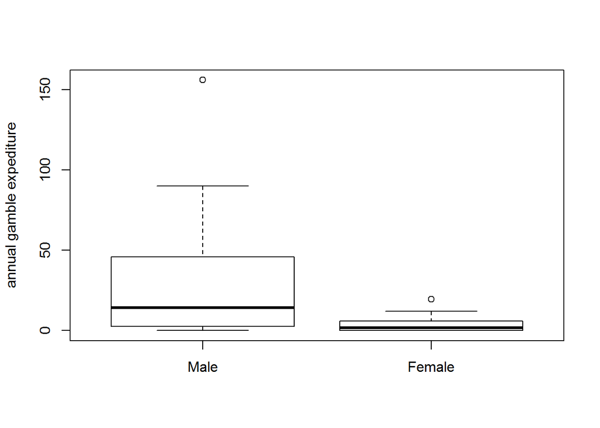

```r
boxplot(gamble~sex, data=teengamb, ylab="annual gamble expediture")
```

남성(0)이 여성(1)보다 높음을 알수 있다.

나머지 부모직업(status), 수입(income), 학업성적(verbal)과 도박지출의 차이를 보자

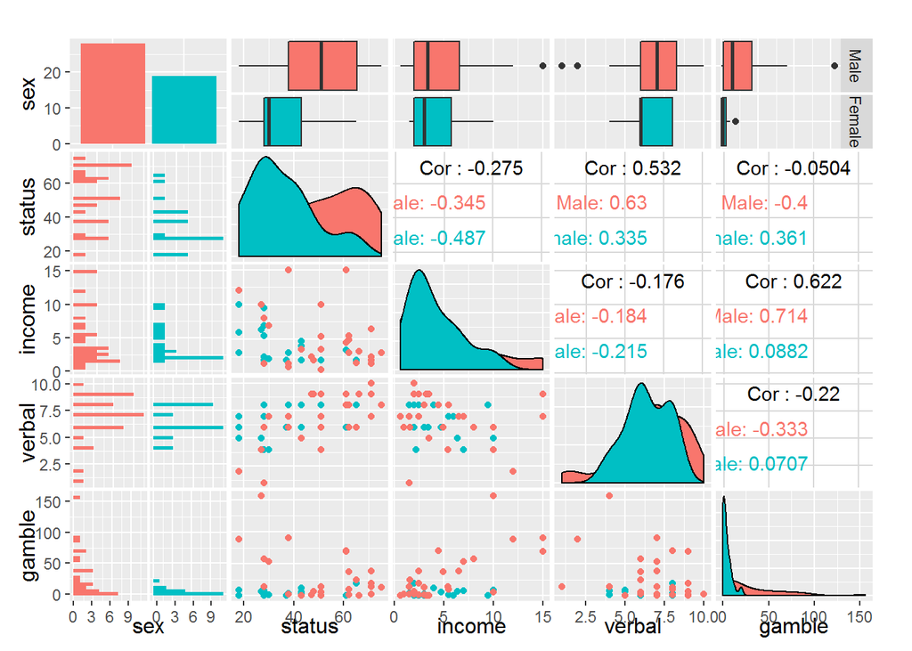

```r
library(ggplot2)
library(GGally)
ggpairs(teengamb, aes(color=sex))
```

위의 plot에서 붉은 색이 남성이고 푸른색이 여성이다. 제일 오른쪽 제일 밑과 위의 칸을 보면 남성에서 도박지출이 높으며, 수입과 도박지출이 양의 상관관계를 가진다(Cor=0.622).

### 2. The dataset teengamb concerns a study of teenage gambling in Britain. Fit a regression model with the expenditure on gambling as the response and the sex, status, income and verbal score as predictors. Present the output.

모델을 만든다.

```r
mdl <- lm(gamble~., data=teengamb)
summary(mdl)
```

```
##
## Call:
## lm(formula = gamble ~ ., data = teengamb)
##
## Residuals:
##     Min      1Q  Median      3Q     Max
## -51.082 -11.320  -1.451   9.452  94.252
##
## Coefficients:
##              Estimate Std. Error t value Pr(>|t|)
## (Intercept)  22.55565   17.19680   1.312   0.1968
## sexFemale   -22.11833    8.21111  -2.694   0.0101 *
## status        0.05223    0.28111   0.186   0.8535
## income        4.96198    1.02539   4.839 1.79e-05 ***
## verbal       -2.95949    2.17215  -1.362   0.1803
## ---
## Signif. codes:  0 '***' 0.001 '**' 0.01 '*' 0.05 '.' 0.1 ' ' 1
##
## Residual standard error: 22.69 on 42 degrees of freedom
## Multiple R-squared:  0.5267, Adjusted R-squared:  0.4816
## F-statistic: 11.69 on 4 and 42 DF,  p-value: 1.815e-06
```

#### (a) What percentage of variation in the response is explained by these predictors?

Multiple R-squared 값이 0.5267 이므로 52.67%의 variation이 현재 모델로 설명된다.

#### (b) Which observation has the largest (positive) residual? Give the case number.

```r
which(residuals(mdl)==max(residuals(mdl)))
```

```
## 24
## 24
```

24

#### (c) Compute the mean and median of the residuals.

```r
mean(residuals(mdl))
```

```
## [1] -3.065293e-17
```

```r
median(residuals(mdl))
```

```
## [1] -1.451392
```

mean : -3.065293e-17 median : -1.451392

#### (d) Compute the correlation of the residuals with the fitted values.

```r
cor(fitted(mdl), residuals(mdl))
```

```
## [1] -1.070659e-16
```

-1.070659e-16으로 0에 가깝다. 따라서 거의 연관성이 없다.

#### (e) Compute the correlation of the residuals with the income.

```r
cor(residuals(mdl), teengamb$income)
```

```
## [1] -7.242382e-17
```

-7.242382e-17으로 0에 가깝다.

#### (f) For all other predictors held constant, what would be the difference in predicted expenditure on gambling for a male compared to a female?

```r
summary(mdl)$coef
```

```
##                 Estimate Std. Error    t value     Pr(>|t|)
## (Intercept)  22.55565063 17.1968034  1.3116188 1.967736e-01
## sexFemale   -22.11833009  8.2111145 -2.6937062 1.011184e-02
## status        0.05223384  0.2811115  0.1858118 8.534869e-01
## income        4.96197922  1.0253923  4.8391032 1.791882e-05
## verbal       -2.95949350  2.1721503 -1.3624718 1.803109e-01
```

다른 변수가 일정할 경우, 여성의 경우 남성보다 22.12 파운드 덜 지출한다.

### 3. In this question, we investigate the relative merits of methods for computing the coefficients. Generate some artificial data by:

`x < - 1:20 > y < - x+rnorm(20)`

```r
set.seed(837)
x <- 1:20
y <- x+rnorm(20)
```

### Fit a polynomial in x for predicting y. Compute in two ways-by `lm ( )` and by using the direct calculation described in the chapter. At what degree of polynomial does the direct calculation method fail? (Note the need for the I ( ) function in fitting the polynomial, that is, `lm(y~x+I(x^2))` .

`lm()’이용한 계산

```r
lm_mdl <- lm(y~x)
l1 <- lm_mdl$coefficients[2]
```

Direct calculation

```r
x <- as.matrix(x)
dir_cal <- function(x,y) {
  return(t(solve(t(x) %*% x, t(x) %*% y)))
}
d1 <- dir_cal(x,y)
```

2항

```r
lm_mdl2 <- lm(y~x+I(x^2))
l2 <- lm_mdl2$coefficients[2:3]

x2 <- matrix(c(x,x^2), nrow=20)
d2 <- dir_cal(x2,y)
```

3항

```r
lm_mdl3 <- lm(y~x+I(x^2)+I(x^3))
l3 <- lm_mdl3$coefficients[2:4]

x3 <- matrix(c(x,x^2,x^3), nrow=20)
d3 <- dir_cal(x3,y)
```

4항

```r
lm_mdl4 <- lm(y~x+I(x^2)+I(x^3)+I(x^4))
l4 <- lm_mdl4$coefficients[2:5]

x4 <- matrix(c(x,x^2,x^3,x^4), nrow=20)
d4 <- dir_cal(x4,y)
```

결과 확인

```
##            x
## lm 0.9854791
##    0.9839254
```

```
##            x      I(x^2)
## lm 0.6932547 0.013915449
##    0.8979795 0.005593302
```

```
##            x       I(x^2)        I(x^3)
## lm 0.3070310  0.058792046 -0.0014246539
##    0.9648055 -0.005292121  0.0003988793
```

```
##           x      I(x^2)       I(x^3)        I(x^4)
## lm 0.278295  0.06460696 -0.001848133  1.008283e-05
##    1.341525 -0.11591963  0.009872517 -2.471997e-04
```

### 4. For the prostate data, fit a model with lpsa as the response and the other variables as predictors.

```r
data("prostate")
prostate$svi <- factor(prostate$svi)
mdl <- lm(lpsa~., data = prostate)
summary(mdl)
```

```
##
## Call:
## lm(formula = lpsa ~ ., data = prostate)
##
## Residuals:
##     Min      1Q  Median      3Q     Max
## -1.7331 -0.3713 -0.0170  0.4141  1.6381
##
## Coefficients:
##              Estimate Std. Error t value Pr(>|t|)
## (Intercept)  0.669337   1.296387   0.516  0.60693
## lcavol       0.587022   0.087920   6.677 2.11e-09 ***
## lweight      0.454467   0.170012   2.673  0.00896 **
## age         -0.019637   0.011173  -1.758  0.08229 .
## lbph         0.107054   0.058449   1.832  0.07040 .
## svi1         0.766157   0.244309   3.136  0.00233 **
## lcp         -0.105474   0.091013  -1.159  0.24964
## gleason      0.045142   0.157465   0.287  0.77503
## pgg45        0.004525   0.004421   1.024  0.30886
## ---
## Signif. codes:  0 '***' 0.001 '**' 0.01 '*' 0.05 '.' 0.1 ' ' 1
##
## Residual standard error: 0.7084 on 88 degrees of freedom
## Multiple R-squared:  0.6548, Adjusted R-squared:  0.6234
## F-statistic: 20.86 on 8 and 88 DF,  p-value: < 2.2e-16
```

#### (a) Compute 90 and 95% CIs for the parameter associated with age. Using just these intervals, what could we have deduced about the p-value for age in the regression summary?

90% CI

```r
summary(mdl)$coeff[4,1]+qt(c(0.05,0.95),df=88)*summary(mdl)$coeff[4,2]
```

```
## [1] -0.038210200 -0.001064151
```

95% CI

```r
summary(mdl)$coeff[4,1]+qt(c(0.025,0.975),df=88)*summary(mdl)$coeff[4,2]
```

```
## [1] -0.041840618  0.002566267
```

#### (b) Compute and display a 95% joint confidence region for the parameters associated with age and lbph. Plot the origin on this display. The location of the origin on the display tells us the outcome of a certain hypothesis test. State that test and its outcome.

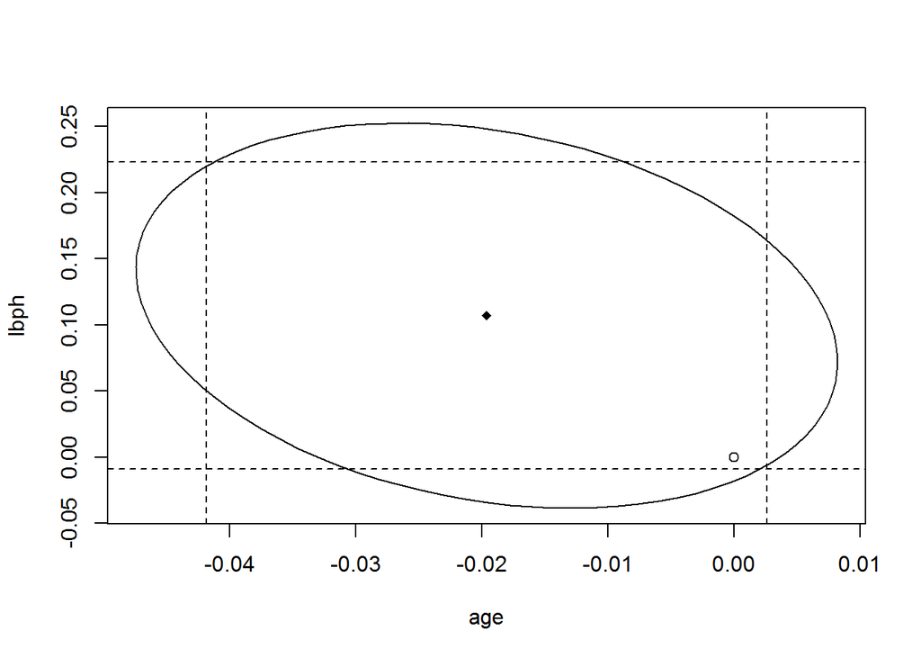

```r
library(ellipse)

plot(ellipse(mdl,c(4,5)),type="l")
points(0,0)
points(mdl$coef[4], mdl$coef[5], pch=18)

abline(v=summary(mdl)$coeff[4,1]+qt(c(0.025,0.975),df=88)*summary(mdl)$coeff[4,2], lty=2)
abline(h=summary(mdl)$coeff[5,1]+qt(c(0.025,0.975),df=88)*summary(mdl)$coeff[5,2], lty=2)
```

위의 그림에서 보면 `age`와 `lbph`의 95% CI 안에 원점이 들어있다. 즉 `age`와 `lbph` 각각 hypothesis test를 시행하면, Null hypothesis를 기각할 수 없다. 또한 원점이 타원 안에 들어있으므로 두 변수의 joint test도 null hypothesis를 기각할 수 없다.

```r
summary(lm(lpsa~age, data=prostate))
```

```
##
## Call:
## lm(formula = lpsa ~ age, data = prostate)
##
## Residuals:
##      Min       1Q   Median       3Q      Max
## -2.90738 -0.71234  0.06967  0.66188  2.99584
##
## Coefficients:
##             Estimate Std. Error t value Pr(>|t|)
## (Intercept)  0.79906    1.00793   0.793   0.4299
## age          0.02629    0.01568   1.677   0.0968 .
## ---
## Signif. codes:  0 '***' 0.001 '**' 0.01 '*' 0.05 '.' 0.1 ' ' 1
##
## Residual standard error: 1.144 on 95 degrees of freedom
## Multiple R-squared:  0.02876,    Adjusted R-squared:  0.01854
## F-statistic: 2.813 on 1 and 95 DF,  p-value: 0.09677
```

```r
summary(lm(lpsa~lbph, data=prostate))
```

```
##
## Call:
## lm(formula = lpsa ~ lbph, data = prostate)
##
## Residuals:
##     Min      1Q  Median      3Q     Max
## -2.6965 -0.7405  0.0013  0.6388  3.0562
##
## Coefficients:
##             Estimate Std. Error t value Pr(>|t|)
## (Intercept)   2.4640     0.1162  21.209   <2e-16 ***
## lbph          0.1431     0.0803   1.782    0.078 .
## ---
## Signif. codes:  0 '***' 0.001 '**' 0.01 '*' 0.05 '.' 0.1 ' ' 1
##
## Residual standard error: 1.141 on 95 degrees of freedom
## Multiple R-squared:  0.03233,    Adjusted R-squared:  0.02215
## F-statistic: 3.174 on 1 and 95 DF,  p-value: 0.07801
```

```r
summary(lm(lpsa~lbph:age, data=prostate))
```

```
##
## Call:
## lm(formula = lpsa ~ lbph:age, data = prostate)
##
## Residuals:
##      Min       1Q   Median       3Q      Max
## -2.73838 -0.76703  0.01612  0.61611  3.06232
##
## Coefficients:
##             Estimate Std. Error t value Pr(>|t|)
## (Intercept) 2.456567   0.116673  21.055   <2e-16 ***
## lbph:age    0.002149   0.001238   1.736   0.0858 .
## ---
## Signif. codes:  0 '***' 0.001 '**' 0.01 '*' 0.05 '.' 0.1 ' ' 1
##
## Residual standard error: 1.142 on 95 degrees of freedom
## Multiple R-squared:  0.03075,    Adjusted R-squared:  0.02055
## F-statistic: 3.014 on 1 and 95 DF,  p-value: 0.08579
```

#### (c) Suppose a new patient with the following values arrives:

```
  cavol  | lweight  | age      | Ibph     | svi     | lcp      | gleason | pgg45    |
  1.44692 |  3.62301 | 65.00000 |  0.30010 | 0.00000 | -0.79851 | 7.00000 | 15.00000 |
```

#### Predict the lpsa for this patient along with an appropriate 95% CI.

```r
predict(mdl, newdata=data.frame(lcavol=1.44692, lweight=3.62301, age=65.00000, lbph=0.30010, svi=factor(0),  lcp=-0.79851, gleason=7, pgg45=15), interval="confidence", conf.int=0.95)
```

```
##        fit      lwr      upr
## 1 2.389053 2.172437 2.605669
```

#### (d) Repeat the last question for a patient with the same values except that he or she is age 20. Explain why the CI is wider.

```r
predict(mdl, newdata=data.frame(lcavol=1.44692, lweight=3.62301, age=20, lbph=0.30010, svi=factor(0),  lcp=-0.79851, gleason=7, pgg45=15), interval="confidence", conf.int=0.95)
```

```
##        fit      lwr      upr
## 1 3.272726 2.260444 4.285007
```

```r
mean(prostate$age)
```

```
## [1] 63.86598
```

`age`의 평균값은 약 63.9이다. 65보다 20이 평균값에서 더 떨어져 있으므로 CI가 넓어진다.

#### (e) In the text, we made a permutation test corresponding to the F-test for the significance of all the predictors. Execute the permutation test corresponding to the t-test for age in this model. (Hint: {summary (g) $coef [4,3] gets you the t-statistic you need if the model is called g.)

```r
tstat <- numeric(1000)

set.seed(12944)
for(i in 1:1000) {
  per_mdl <- lm(sample(lpsa)~.,data=prostate)
  tstat[i] <- summary(per_mdl)$coef[4,3]
}
length(tstat[abs(tstat) > abs(summary(mdl)$coef[4,3])])/1000
```

```
## [1] 0.073
```

Permutation test의 결과, original data에서 계산된 모델에서 `age`의 t값의 절대값보다보다 더 큰 절대값의 t값을 얻을 확률은 0.073이다. 이것은 모델에서 계산된 0.082와 비슷한 값이다. 그러나 여전히 0.05 보다 크기 때문에 0.05 유의수준에서 Estimate가 0이라는 귀무가설을 기각할 수 없는 값이다.